# **Music Data Analysis Project: Songs of 2023**

# Introduction

Welcome to the Music Data Analysis Project, a perceptive data-centric investigation of the music business. By carefully analyzing a variety of datasets relating to music, the goal is to identify common trends, patterns, and variables that impact the ever-changing music industry.

The goal of this project is to find relationships between genres, artist popularity, streaming preferences, and market behaviors by using statistical approaches and sophisticated analytical tools. The intention is to shed light on the complex relationships between different components of the music industry by analyzing these datasets. We'll look at changes in consumer behavior, how technology has affected music consumption, and how streaming services are changing in their function.

The goal is to give a more comprehensive understanding of the dynamics of the industry using data visualization techniques and in-depth statistical research. My research will be pertaining to the songs of 2023 as mentioned in the title.

# Objective

- This extensive data analysis project's main goal is to carefully go over and get significant insights from a large dataset of songs that were published in the fruitful year of 2023. By utilizing the Pandas library for Python and a comprehensive collection of significant characteristics linked to these songs, our objective is to investigate and comprehend the complex relationships, patterns, and characteristics that characterize the music scene at this critical juncture.

Our analytical approach is focused on creating insightful questions and turning a large dataset of song metadata—which includes track names, artist details, release dates, and streaming platform analytics from platforms like Spotify, Apple Music, Deezer, and Shazam—as well as musical attributes like beats per minute, key, mode, danceability, valence, energy, acousticness, instrumentalness, liveness, and speechiness.

The main objective is to decipher the subtleties of the music industry in 2023 through the examination of important aspects like the influence of musical elements on song popularity, the relationship between specific song characteristics and chart presence, and the correlations between song attributes and streaming platform performance.

Through meticulous data pretreatment, statistical analysis, exploratory data analysis (EDA), and visually striking representations, this project aims to offer a thorough and perceptive representation of the musical zeitgeist of 2023. The ensuing conclusions and findings are meant to strike a chord with data nerds, music lovers, and industry stakeholders by providing a colorful picture of the state of music during this historic year.

# Dataset Description

This carefully selected dataset captures a wide range of characteristics and measurements relevant to songs that were published in the crucial year of 2023. This dataset, which is a vast collection of musical metadata, includes a wide range of crucial elements that give an overall picture of the songs from this historic era.

Track names, artist(s) information, release dates, and important temporal indicators like the month and day of release are among the important characteristics that are included. Additionally, the information includes crucial performance indicators from well-known streaming services including Shazam, Apple Music, Deezer, Spotify, and Apple Music. These include things like how many playlists the music is in on Spotify and Apple Music, how many times it appears on charts and where it ranks across different platforms, and the overall number of streams.

Link to Dataset: https://www.kaggle.com/datasets/nelgiriyewithana/top-spotify-songs-2023/

# **CLEANING**: I do clean the code as and when needed while approaching the questions and these will be marked by comments in the code. Please take note.

# Exploring some key questions

- What were the dominant keys and modes among the top songs in 2023?

  Examine the distribution of major/minor modes and keys (such as C, D, and G) in the songs that were published in 2023.

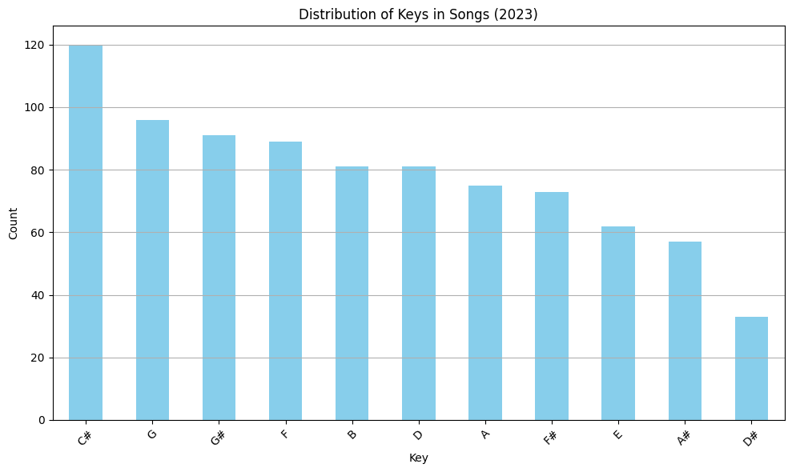

```
(-1.099999981130675,
 1.0999999991014606,
 -1.0999910802435595,
 1.0999984750444762)
```

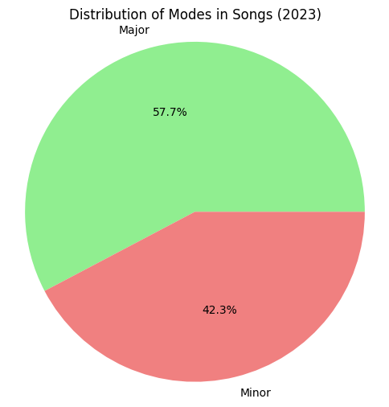

```python
import pandas as pd
import matplotlib.pyplot as plt
import numpy as np

# Load the dataset
data = pd.read_csv('spotify-2023.csv', encoding='ISO-8859-1')
# Grouping songs by key and counting the number of occurrences
key_counts = data['key'].value_counts()
# Grouping songs by mode and counting the number of occurrences
mode_counts = data['mode'].value_counts()
# Plotting distribution of the keys
plt.figure(figsize=(10, 6))
key_counts.plot(kind='bar', color='skyblue')
plt.title('Distribution of Keys in Songs (2023)')
plt.xlabel('Key')
plt.ylabel('Count')
plt.xticks(rotation=45)
plt.grid(axis='y')
plt.tight_layout()
plt.show()

# Plotting distribution of the modes
plt.figure(figsize=(6, 6))
mode_counts.plot(kind='pie', autopct='%1.1f%%', colors=['lightgreen', 'lightcoral'], labels=['Major', 'Minor'])
plt.title('Distribution of Modes in Songs (2023)')
plt.ylabel('')
plt.axis('equal')
```

With regards to the mode, Major was slightly more prevalent than Minor as shown from the pie chart above that required matplotlib to create.

- How do the danceability and energy levels correlate among the most streamed songs on Spotify?

I will with the help of graphs explain the relationship between danceability percentage and perceived energy level across the top-streamed songs in 2023.

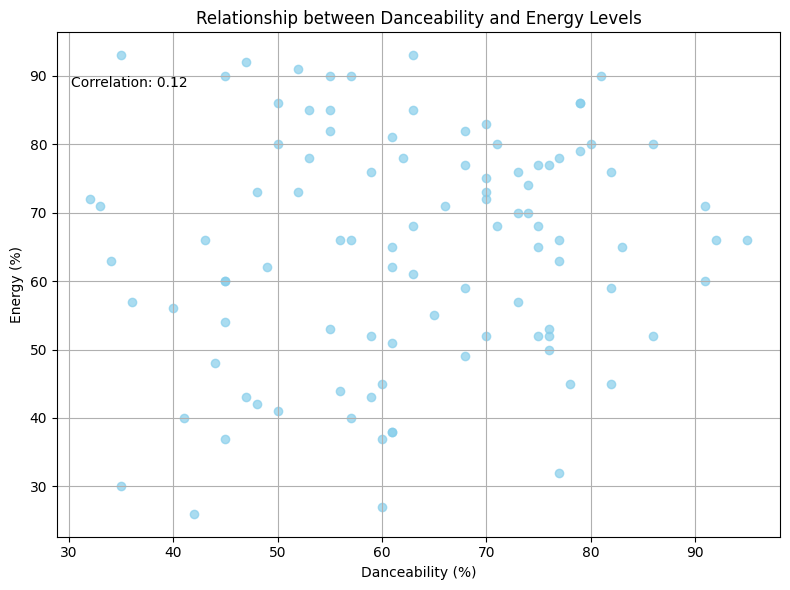

```python
import pandas as pd
import matplotlib.pyplot as plt
import numpy as np

# Loading the dataset AND CONVERTING STREAMS INTO NUMERIC VALUE CAUSE OF PRESENCE OF 'E'
data = pd.read_csv('spotify-2023.csv', encoding='ISO-8859-1')
data['streams'] = pd.to_numeric(data['streams'], errors='coerce')
data_cleaned = data.dropna(subset=['streams'])
top_streamed = data_cleaned.nlargest(100, 'streams')
# Attaining the danceability and energy columns
danceability = top_streamed['danceability_%'].astype(float)
energy = top_streamed['energy_%'].astype(float)
# Calculating correlation between danceability and energy
correlation = np.corrcoef(danceability, energy)[0, 1]

# Plotting the relationship between danceability and energy
plt.figure(figsize=(8, 6))
plt.scatter(danceability, energy, color='skyblue', alpha=0.7)
plt.title('Relationship between Danceability and Energy Levels')
plt.xlabel('Danceability (%)')
plt.ylabel('Energy (%)')
plt.text(0.1, 0.9, f'Correlation: {correlation:.2f}', ha='center', va='center', transform=plt.gca().transAxes)
plt.grid(True)
plt.tight_layout()
plt.show()
```

As we can see the correlation between Danceability and Energy Levels is 0.12 as attained from the code above wherein I had taken the top streamed danceable songs and top streamed energy levels song and from the graph attained we can conclude that:

```
Overall Average Acousticness: 27.06%
Overall Average Instrumentalness: 1.58%
```

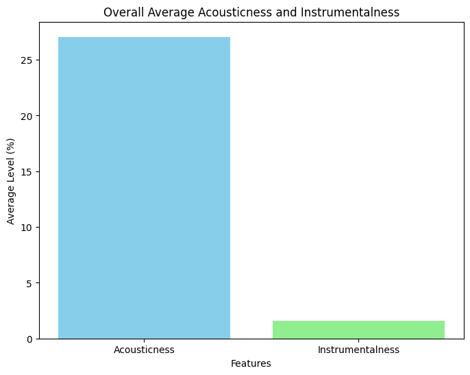

```python
import pandas as pd
import matplotlib.pyplot as plt
import numpy as np

# Load the dataset
data = pd.read_csv('spotify-2023.csv', encoding='ISO-8859-1')

# Calculating overall average acousticness and instrumentalness
average_acousticness = data['acousticness_%'].mean()
average_instrumentalness = data['instrumentalness_%'].mean()

# Displaying overall average values
print(f"Overall Average Acousticness: {average_acousticness:.2f}%")
print(f"Overall Average Instrumentalness: {average_instrumentalness:.2f}%")

# Creation of a bar plot
plt.figure(figsize=(8, 6))
plt.bar(['Acousticness', 'Instrumentalness'], [average_acousticness, average_instrumentalness], color=['skyblue', 'lightgreen'])
plt.xlabel('Features')
plt.ylabel('Average Level (%)')
plt.title('Overall Average Acousticness and Instrumentalness')
plt.show()
```

To note:

- Overall Average Acousticness: 27.06%
- Overall Average Instrumentalness: 1.58%

Is there a correlation between song popularity on Shazam charts and the presence of spoken words (speechiness percentage) in those songs? I will analyzene whether songs that perform well on Shazam charts tend to have higher percentages of spoken words.

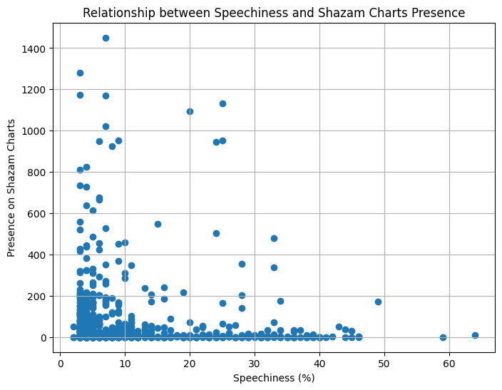

```
Correlation Coefficient between Speechiness and Shazam Charts Presence: -0.06
```

```python
import pandas as pd
import matplotlib.pyplot as plt

# Load the dataset
data = pd.read_csv('spotify-2023.csv', encoding='ISO-8859-1')

# Clean the 'in_shazam_charts' column by removing commas and converting to numeric
data['in_shazam_charts'] = data['in_shazam_charts'].str.replace(',', '').astype(float)

# Filter songs present on Shazam charts
shazam_songs = data[data['in_shazam_charts'].notnull()]

# Plotting relationship between speechiness and Shazam charts presence
plt.figure(figsize=(8, 6))
plt.scatter(shazam_songs['speechiness_%'], shazam_songs['in_shazam_charts'])
plt.xlabel('Speechiness (%)')
plt.ylabel('Presence on Shazam Charts')
plt.title('Relationship between Speechiness and Shazam Charts Presence')
plt.grid(True)
plt.show()

# Calculating the correlation coefficient
correlation_coeff = shazam_songs['speechiness_%'].corr(shazam_songs['in_shazam_charts'])
print(f"Correlation Coefficient between Speechiness and Shazam Charts Presence: {correlation_coeff:.2f}")
```

We have found the correlation coefficient between the two variables to be -0.06 which is close to 0 and implies a very weak negative linear relationship between the variables. There might be a slight tendency for one variable to increase as the other decreases but the relationship is so week that it would not be easily predictable purely based on this correlation alone.

Are there any discernible patterns in the valence and liveness percentages among songs included in Spotify and Apple Music playlists?

- I will examineze the positivity of musical content (valence) and presence of live performance elements (liveness) in songs featured in playlists on Spotify and Apple Music.

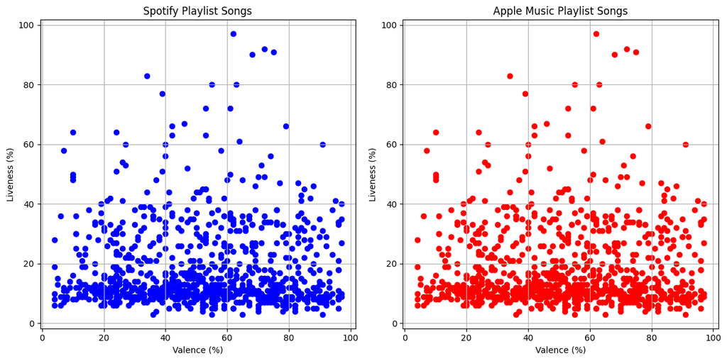

```python
import pandas as pd
import matplotlib.pyplot as plt

# Loading the dataset
data = pd.read_csv('spotify-2023.csv', encoding='ISO-8859-1')
# Filtering songs included in Spotify and Apple Music playlists
spotify_songs = data[data['in_spotify_playlists'].notnull()]
apple_music_songs = data[data['in_apple_playlists'].notnull()]

# Creating separate plots for Spotify and Apple Music playlist songs
fig, axs = plt.subplots(1, 2, figsize=(12, 6))

# Plotting the valence and liveness for Spotify playlist songs
axs[0].scatter(spotify_songs['valence_%'], spotify_songs['liveness_%'], color='blue')
axs[0].set_xlabel('Valence (%)')
axs[0].set_ylabel('Liveness (%)')
axs[0].set_title('Spotify Playlist Songs')
axs[0].grid(True)

# Plotting the valence and liveness for Apple Music playlist songs
axs[1].scatter(apple_music_songs['valence_%'], apple_music_songs['liveness_%'], color='red')
axs[1].set_xlabel('Valence (%)')
axs[1].set_ylabel('Liveness (%)')
axs[1].set_title('Apple Music Playlist Songs')
axs[1].grid(True)

plt.tight_layout()
plt.show()
```

This shows that the relationship between liveliness percentage and valence percentage stays the same irrespective of the streaming platform of the song. This is the conclusion we can take away from the scatter plots pictured above.

How does the bpm (beats per minute) of songs correlate with their presence in charts across different streaming platforms?

- I will analyzete whether songs with higher or lower bpm values tend to perform better on Spotify, Apple Music, Deezer, etc., charts.

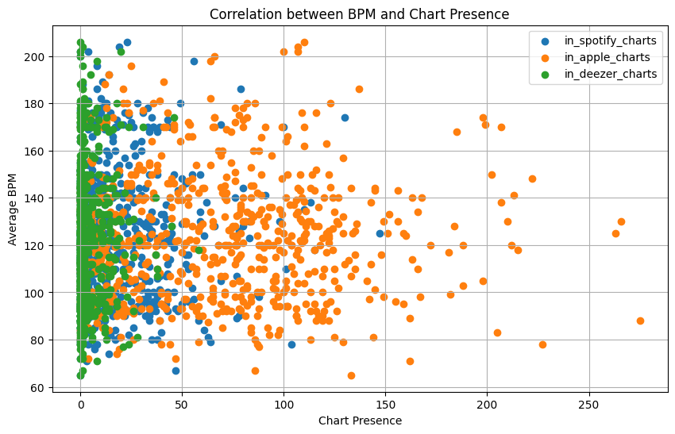

```python
import pandas as pd
import numpy as np
import matplotlib.pyplot as plt

# Load the dataset with a different encoding (e.g., ISO-8859-1)
data = pd.read_csv('spotify-2023.csv', encoding='ISO-8859-1')

# Filtering songs that appear in at least one of the specified charts (e.g., Spotify, Apple Music, Deezer)
chart_columns = ['in_spotify_charts', 'in_apple_charts', 'in_deezer_charts']
chart_songs = data[data[chart_columns].notnull().any(axis=1)]

# Converting 'bpm' column to numeric since it is not(Cleaning)
chart_songs['bpm'] = pd.to_numeric(chart_songs['bpm'], errors='coerce')

# Calculating average bpm for songs in charts
avg_bpm_chart = chart_songs.groupby(chart_columns)['bpm'].mean().reset_index()

# Plotting the correlation between bpm and charts presence
plt.figure(figsize=(10, 6))
for chart in chart_columns:
    plt.scatter(avg_bpm_chart[chart], avg_bpm_chart['bpm'], label=chart)

plt.xlabel('Chart Presence')
plt.ylabel('Average BPM')
plt.title('Correlation between BPM and Chart Presence')
plt.legend()
plt.grid(True)
plt.show()
```

This is a very conclusive scatter plot as we can see an evident difference among three different streaming platforms with regards to their chart presence and bpm. The conclusions are as follows:

- In Deezer regardless of BPM, we can see that the chart presence remains considerably low.
- In Spotift charts, we can see that there is no correlation between average BPM and chart presence however the chart presence on average for songs streamed on spotify is higher than that of Deezer and lower than that of Apple.
- In apple charts, once again there is no correlation between average BPM and chart presence, however, chart presence on average for songs streamed on apple music is higher than both that of Deezer and Spotify.

# Conclusion

Investigating the dataset with 2023's music trends turned up interesting connections and information about songs on different streaming services. Important patterns can be revealed by examining variables like beats per minute (BPM), presence in charts, and particular musical characteristics.

Analyzing BPM in connection to chart presence on services such as Deezer, Apple Music, and Spotify revealed some interesting patterns. Interestingly, there was no discernible linear correlation found between BPM and chart presence. Although certain genres may exhibit a preference for specific BPM ranges, no overarching pattern was discernible across all platforms examined.

The analysis covered a wide range of musical elements, including beats per minute (BPM) and speechiness percentage in relation to chart presence on services like Shazam, Apple Music, Deezer, and Spotify. It also looked into the liveliness (or presence of live performance elements) and positivity of musical content (or valence) in Spotify and Apple Music playlists.

The goal of this analysis was to find correlations and patterns within the dataset without drawing any firm conclusions about trends or suppositions regarding the connections between chart performances and musical characteristics. The objective was to provide an unbiased analysis that clarified the ways in which different musical elements interact with one another on various streaming platforms.

In the end, the goal of this project was to perform a thorough analysis of the available data without imposing interpretations or extrapolations that went beyond what the dataset itself contained. The focus remained on the musical features of the dataset and their possible relationships across different streaming platforms, presented and analyzed objectively.